# 과적합화문제해결

JJ

2018년 9월 19일

# 1 일반화

일반화: 모델 제작에 사용되지 않은 모든 데이터에도 모델을 적용할 수 있는 성질

# 2 과적합화

과적합화: 이 문제에서는 통신사 고객이 모집단인데, 훈련 데이터에만 딱 맞는 모델을 만들어, 데이터 마이닝을 통해 훈련데이터 외에도 적용할 수 있는 일반화된 모델을 만들지 못했다.

아직 학습하지 않은 데이터에 대한 일반화는 희생하고 훈련 데이터에만 모델을 맞추려는 경향 모든 마이닝 절차에는 어느 정도 과적합화 경향이 있음(앞의 예는 극단적)

과적합화는 알아내기도 쉽지 않고, 과적합화 되지 않은 데이터 마이닝 절차를 사용할 수 있는 것도 아니다. 모델 복잡도와 과적합화 문제는 동전의 양면

과적합화되어 있는지를 알아내고 원칙에 따라 복잡도를 관리하는 전략이 가장 좋다. 이슈1. 과적합화 정도의 측정 이슈2. 가능한 한 과적합화를 피하는 방법

# 3 과적합화 검사

## 3.1 예비 데이터와 적합도 그래프

예비 데이터 타겟 변수값은 알지만 모델 생성에 사용되지 않은 데이터 타겟 변수값을 예측할 실제 데이터는 아니지만 실험실에서 모델의 일반화 성능을 측정하기 위해 떼어 놓은 데이터 시험 세트

적합도 그래프: 모델 복잡도에 따른 정확도 Step1. 모델 복잡도 낮고, 정확도 낮음 Step2. 모델 복잡도 중간, 정확도 최적 Step3. 모델 복잡도 높고, 정확도 낮아짐(과적합화)

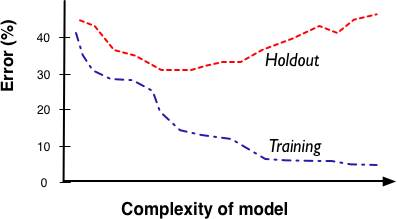

고객 이탈 모델에 대한 적합도 그래프

## 3.2 트리 유도에서의 과적합화

과적합 모델

트리의 단말 노드에 데이터가 하나만 있을 때까지 분할 (극단적인 과적합 모델링) 훈련데이터에 대해서는 100%의 성능 테이블 모델 보다는 나은 모델 새로운 데이터에 대해 단말 노드 결정이 가능하기 때문 트리의 복잡도는 노드의 수

적합도 그래프

스위트 스팟(SS) 이론적으로 SS를 찾아내는 방법은 아직 미존재 경험적으로 SS를 찾아야 함.

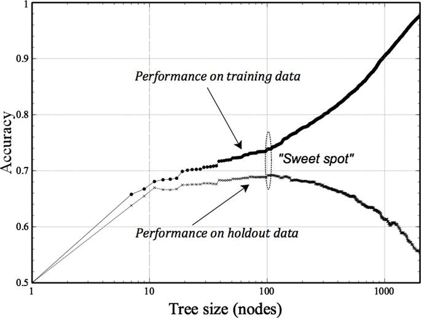

## 3.3 수학 함수에서의 과적합화

함수가 복잡해지는 이유: 모델에 속성을 추가하기 때문이다. 기존 속성의 제곱, 기존 속성간 비율 추가 f(x) = w0 + w1x1 + w2x2 + w3x3 + -> f(x) = w0 + w1x1 + w2x2 + w3x3 + w4x4 + w5x5 (x4 = x12 , x5 = x2 / x3) 차원을 늘리면 적합도가 증가함.

데이터 마이닝 현황

수많은 모델을 아예 자동으로 만들거나 속성이 너무 많아 수작업으로 속성을 선택하기는 어려움

예시) 온라인 광고를 출력하는 기업의 경우 매주 수백만 개의 특징을 이용해 수천 개의 모델을 만들어야 하는 경우

# 4 사례: 선형 함수 과적합화

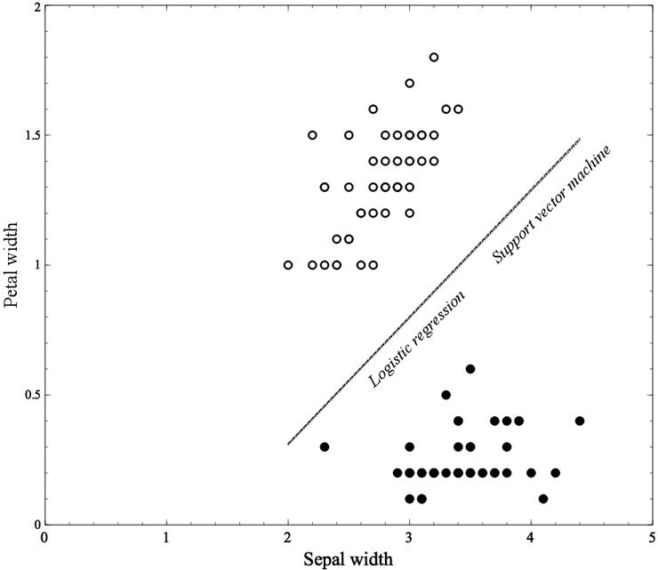

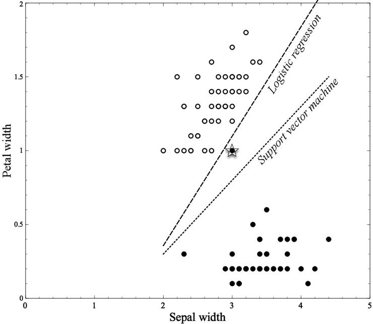

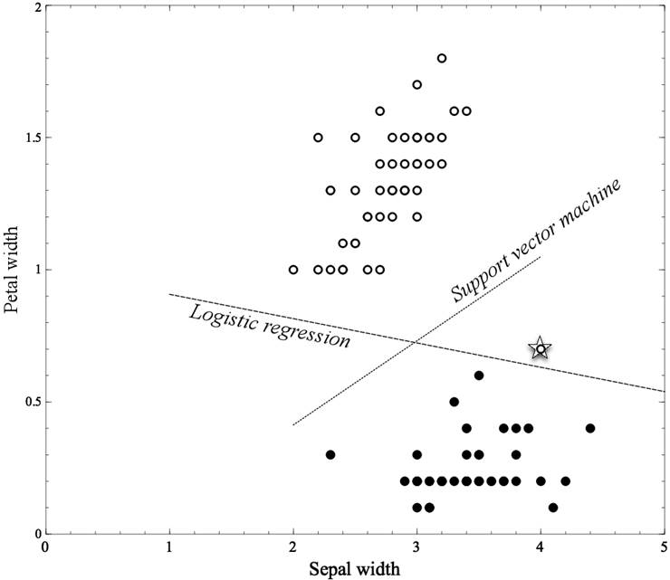

# 5 사례: 왜 과적합화가 문제인가?

왜 성능이 떨어질까? 모델이 복잡해지면서 해로운 가짜 연관성까지 학습하게 되기 때문 가짜 연관성은 훈련 세트에만 존재하는 특이한 성질 일반화 X

교재 p.156-157 모집단 설명  훈련데이터 설명(표)  분류트리 모델 (a) 설명  (b) 과적합 설명 (b)의 오류율은 30%, (a)의 예상 오류율은 25%

과적합화 문제는 분류트리에만 국한되지 않는다. 모집단으로부터 추출된 유한 표본은 편향되어 있지 않더라도 변이를 포함한다. 모집단 전체에 대해 알고 있는 경우는 거의 없으므로 예비 데이터를 이용해 과적합화 여부를 알아내는 것이 좋다. (과적합화를 알아내는 이론적인 분석 방법이 없으므로)

# 6 예비 데이터 평가에서 교차 검증까지

단 한 세트에 대한 추정일 뿐  정확도에 대한 확신?

교차 검증(Cross Validation)

더욱 정교한 예비 훈련 및 시험 절차 일반화 성능을 딱 한번 추정하는 대신 평균이나 변이와 같은 추정된 성능에 대한 통계 데이터를 갖게 되면 데이터 세트에 따라 성능이 어떻게 바뀔지 예측할 수 있다. 여러 번 분할하고 시험하기 위한 표본을 체계적으로 바꿔가면서 모든 데이터에 대해 추정치를 계산

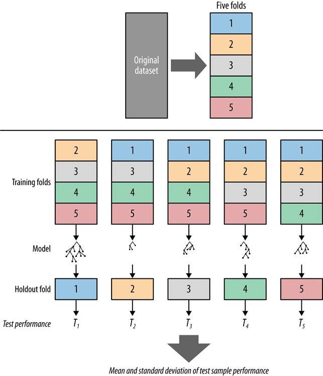

# 7 5.7 다시 모델링한 고객 이탈 문제

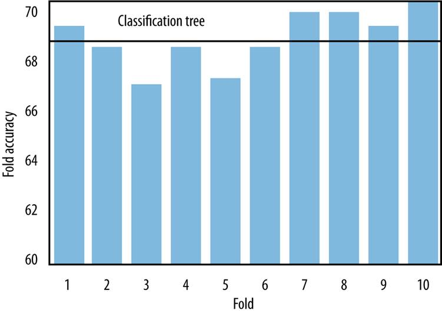

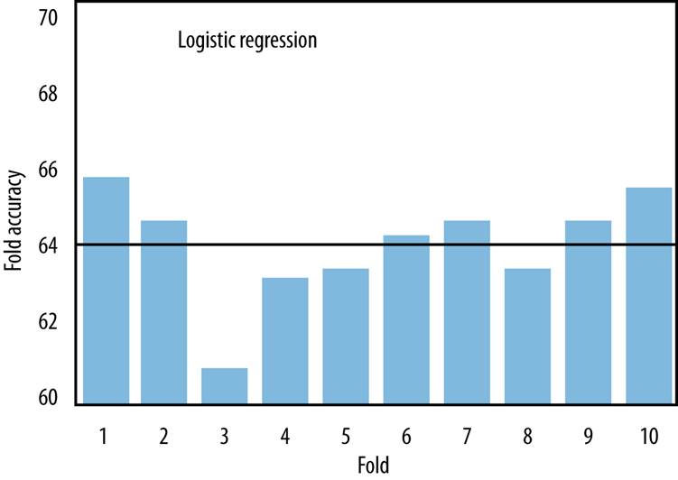

# 8 5.8 학습 곡선

학습곡선

훈련 데이터 양 증가에 따른 일반화 성능을 보여주는 그래프 로지스틱 회귀 분석 (데이터 적을 때) 융통성이 떨어짐 데이터가 적을 때는 과적합화가 덜 일어남 복잡한 데이터는 완전히 모델링하지 못함.

트리 유도 (데이터 많을 때)

융통성이 좋음 데이터가 적을 때는 과적합화가 일어나기 쉬움 훈련 데이터가 커지면 복잡한 규칙도 잘 모델링

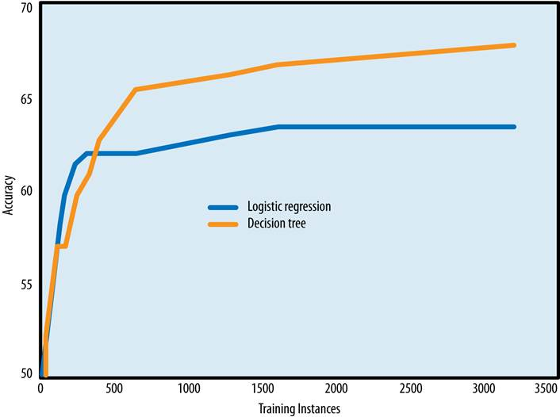

적합도 그래프 vs 학습곡선

학습곡선 x 축은 훈련 데이터의 크기 일반화 성능을 보여줌

적합도 그래프

훈련 데이터의 크기를 고정 x 축은 모델의 복잡도 (노드의 수) 훈련 데이터에 대한 성능, 일반화 성능 표현

학습 곡선 사용례

데이터가 자산 학습 곡선을 그렸을 때 일반화 성능이 향상되어야 의미 있음. 데이터 확보에 투자

일반화 성능이 향상되지 않는다면

훈련 데이터 수집에 투자하는 것은 무의미 성능 개선 방안 더 나은 특징(변수)을 고안하는 등 모델을 개선할 다른 방법을 찾아야 함.

# 9 과적합화 회피와 복잡도 제어

## 9.1 과적합화 회피와 복잡도 제어

트리유도의 가장 큰 문제점

단말 노드가 순수해질 때까지 훈련 데이터에 맞춰 트리를 계속 키우려고 한다는 점 데이터에 과적합화된 지나치게 크고 복잡한 트리가 만들어진다.

과적합화를 피하기 위한 두 가지 방법

너무 복잡해지기 전에 트리의 성장을 멈추게 한다. 트리를 최대한 키운 후에 프루닝해 크기를 줄인다. ->단말 노드에 들어가는 객체의 최소 한도 정하기

장점: 많은 데이터 가지들은 커지고, 적은 가지는 짧아짐, 데이터 분산에 따라 자동으로 모델을 적응

단점: 임계치를 얼마로 설정?  해결책: 분기에 따른 정보량 증가가 우연인지에 대한 가설 검증(p-값 이용) p-값이 5%보다 적으면 계속 분기 ->지나치게 큰 트리를 프루닝

## 9.2 과적합화를 피하기 위한 일반적인 방법

동일 데이터에 복잡도가 다른 모델이 여러 개 있을 때의 선택 방법

-방법: 레이블이 붙은 시험 데이터를 이용: 시험 데이터가 모델 생성과정에 관여 +내포된 예비 시험(Nested Holdout Test): 훈련 세트를 하위 훈련 세트와 시험 세트로 분할 모델 생성

-절차: 훈련 세트의 하위 세트를 만들어 모델 복잡도를 결정하고, 훈련세트 전체를 이용해 최종 모델을 만들고, 예비 세트로 일반화 성능 검증 +하위 세트를 이용한 모델의 복잡도 결정  모델 생성  일반화 성능 검증

-복잡도를 제어하는 실험적인 모델링은 계산 부담 때문에 실무에 널리 응용된지 10여 년밖에 안된다

-응용

+다른 유도 알고리즘이나 다양한 복잡도에 적용 +특징 집합을 줄이려면 여러 특징 집합으로 내포된 예비 절차를 실행해 최고의 모델을 골라 내는 것이 좋다. (순차 전진 선택, 순차 후진 제거)

## 9.3 파라미터 최적화에서 과적합화 피하기

데이터에 대한 적합도와 모델에 대한 복잡도 사이에 “올바른“ 균형 잡기

균일화: 모델을 데이터에 적합화하는 것과 단순함 모두를 최적화하는 것

격자 검색(Grid Search): 훈련 데이터에 내포된 교차 검증을 통해 파라미터값을 최적화하는 방법